# Lecture 13: Generalized Linear Models

PSTAT100: Data Science — Concepts and Analysis

John Inston

johninston@ucsb.edu

University of California, Santa Barbara

October 29, 2026

## 🚁 Overview

### Aims of the lecture

- Identify the **limitations of linear regression** when the response is not continuous.
- Introduce the **Generalized Linear Model (GLM)** framework: exponential family, link functions, and maximum likelihood estimation.
- Derive and interpret **logistic regression** for binary responses.
- Introduce **Poisson regression** for count responses.
- Fit GLMs in Python using `statsmodels` and interpret outputs, diagnostics, and model comparisons.

### 📚 Required Libraries

```python
import numpy as np
import pandas as pd
import matplotlib.pyplot as plt
import seaborn as sns
from scipy.stats import norm, binom
from scipy.special import expit          # the logistic (sigmoid) function
import statsmodels.formula.api as smf
import statsmodels.api as sm
from statsmodels.stats.anova import anova_lm
from sklearn.metrics import (
    confusion_matrix, ConfusionMatrixDisplay,
    roc_curve, roc_auc_score
)
```

### 💅 Figure Styles

```python
sns.set_style('whitegrid')
sns.set_palette('Set2')
```

# The Limits of Linear Regression

## 🤔 When Does Linear Regression Break Down?

### Recall the assumptions

- The MLR model assumes $Y_i \sim \mathcal{N}(\mu_i, \sigma^2)$ with $\mu_i = \mathbf{x}_i^\top \boldsymbol{\beta}$.
- The **mean** $\mu_i$ is modelled as an unrestricted linear combination of predictors.

### But many responses are not continuous or Gaussian

| Response type | Example | Problem with linear regression |
| --- | --- | --- |
| **Binary** | Patient survived / died | Predictions outside $[0, 1]$; errors not normal |
| **Count** | Number of insurance claims | Must be non-negative; variance grows with mean |
| **Proportion** | Percentage of votes won | Bounded in $[0, 1]$; heteroscedastic |
| **Positive continuous** | Hospital length of stay | Right-skewed; errors non-normal |

## A Concrete Problem: Predicting a Binary Outcome

### Can we predict whether a passenger survived the Titanic?

- $Y_i \in \{0, 1\}$ — **binary** response.
- We want to model $P(Y_i = 1 \mid \mathbf{x}_i)$ — the **probability** of survival.

### What goes wrong with OLS?

```python
rng = np.random.default_rng(0)
x = np.linspace(-3, 3, 200)
p_true = expit(2 * x)
y = rng.binomial(1, p_true)

X_ols = sm.add_constant(x)
ols_fit = sm.OLS(y, X_ols).fit()

fig, axes = plt.subplots(1, 2, figsize=(12, 4))

axes[0].scatter(x, y, alpha=0.4, color='steelblue', s=20, label='Observed $Y \in \{0,1\}$')
axes[0].plot(x, ols_fit.fittedvalues, color='crimson', lw=2, label='OLS fitted line')
axes[0].axhline(0, color='gray', lw=1, linestyle='--')
axes[0].axhline(1, color='gray', lw=1, linestyle='--')
axes[0].set_xlabel('$X$'); axes[0].set_ylabel('$Y$')
axes[0].set_title('OLS on Binary Response')
axes[0].legend(fontsize=9)

axes[1].scatter(ols_fit.fittedvalues, ols_fit.resid, alpha=0.4, color='steelblue', s=20)
axes[1].axhline(0, color='crimson', lw=1.5, linestyle='--')
axes[1].set_xlabel('Fitted values'); axes[1].set_ylabel('Residuals')
axes[1].set_title('Residuals vs. Fitted (OLS on Binary Response)')

plt.tight_layout(); plt.show()
```

## A Concrete Problem: Predicting a Binary Outcome

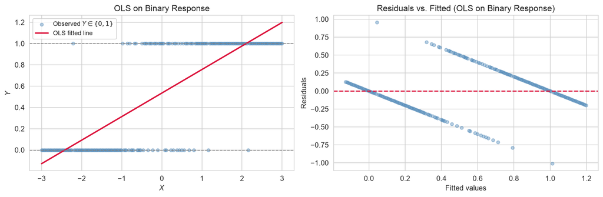

OLS fitted to a binary outcome: predicted values fall outside [0, 1] for extreme predictor values, and the residuals are clearly non-normal.

# The Generalized Linear Model

## 🏗️ The Three Components of a GLM

**Generalized Linear Model (GLM)**

A **GLM** extends linear regression by relaxing the normality assumption. It has three components:

1. **Random component**: the response $Y_i$ follows a distribution from the **exponential family** with mean $\mu_i = \mathbb{E}[Y_i]$.
2. **Systematic component**: a linear predictor $\eta_i = \mathbf{x}_i^\top \boldsymbol{\beta}$.
3. **Link function** $g$: connects the mean to the linear predictor, $g(\mu_i) = \eta_i$.

### The key idea

- We no longer model $\mu_i$ **directly** as a linear combination.
- Instead, we model a **transformation** of $\mu_i$ linearly: $g(\mu_i) = \eta_i = \mathbf{x}_i^\top \boldsymbol{\beta}$.
- The link function ensures that $\mu_i$ stays in the valid range for the chosen distribution.

## The Exponential Family

A distribution belongs to the **exponential family** if its probability density/mass function can be written as

$$f(y \mid \theta, \phi) = \exp\!\left\{\frac{y\theta - b(\theta)}{a(\phi)} + c(y, \phi)\right\},$$

where $\theta$ is the **canonical parameter**, $\phi$ is the **dispersion parameter**, and $b(\cdot)$, $a(\cdot)$, $c(\cdot)$ are known functions. Note the following important properties:

- $\mu = \mathbb{E}[Y] = b'(\theta)$.
- $\text{Var}(Y) = b''(\theta)\,a(\phi)$ — variance is a function of the mean.

| Distribution | Response type | Canonical link $g(\mu)$ |
| --- | --- | --- |
| Normal | Continuous $(-\infty, \infty)$ | Identity: $g(\mu) = \mu$ |
| Bernoulli/Binomial | Binary / proportion $[0,1]$ | Logit: $g(\mu) = \log\frac{\mu}{1-\mu}$ |
| Poisson | Count $\{0, 1, 2, \ldots\}$ | Log: $g(\mu) = \log\mu$ |
| Gamma | Positive continuous $(0, \infty)$ | Inverse: $g(\mu) = 1/\mu$ |

## Link Functions

### What does the link function do?

- The link function $g$ maps the **mean** $\mu_i$ (which must lie in a constrained range) to the **real line**.
- The **inverse** $g^{-1}(\eta_i) = \mu_i$ then maps the linear predictor back to a valid mean.

### Canonical vs. non-canonical links

- The **canonical link** is the natural choice derived from the exponential family form.
- Other links can be used if they make scientific sense — the canonical link is often used as a default.

## Link Function Visualization

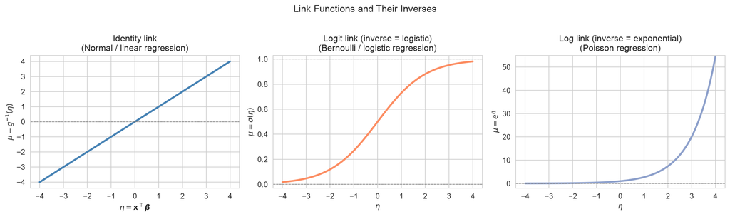

The three most commonly used link functions and their inverses: identity (linear regression), logit (logistic regression), and log (Poisson regression).

## Estimation: Maximum Likelihood

### Why not OLS?

- OLS minimises the **sum of squared residuals** — optimal when errors are Gaussian.
- For non-Gaussian responses, squared residuals are no longer the right loss.

### Maximum likelihood estimation

- GLMs are estimated by **maximising the log-likelihood** of the data given $\boldsymbol{\beta}$.
- The log-likelihood for a GLM is:

$$\ell(\boldsymbol{\beta}) = \sum_{i=1}^n \frac{y_i \theta_i - b(\theta_i)}{a(\phi)} + \text{const}.$$

- There is **no closed-form solution** in general — we use **iteratively reweighted least squares (IRLS)**, an iterative numerical algorithm.
- `statsmodels` handles this automatically.

## Iteratively Reweighted Least Squares (IRLS) I

### The key insight

- The score equations $\nabla_{\boldsymbol{\beta}}\,\ell(\boldsymbol{\beta}) = \mathbf{0}$ cannot be solved directly.
- IRLS recasts MLE as a **sequence of weighted least squares problems**, each of which has a closed-form solution.

### One iteration of IRLS

At the current estimate $\boldsymbol{\beta}^{(t)}$, compute:

| Quantity | Formula | Role |
| --- | --- | --- |
| Fitted means | $\hat{\mu}_i = g^{-1}(\mathbf{x}_i^\top\boldsymbol{\beta}^{(t)})$ | Current predicted means |
| Weights | $w_i = \frac{1}{V(\hat{\mu}_i)\,[g'(\hat{\mu}_i)]^2}$ | Downweight noisy observations |
| Working response | $z_i = \eta_i + (y_i - \hat{\mu}_i)\,g'(\hat{\mu}_i)$ | Linearised pseudo-response |

## Iteratively Reweighted Least Squares (IRLS) II

Then solve the **weighted least squares** problem:

$$\boldsymbol{\beta}^{(t+1)} = \left(\mathbf{X}^\top \mathbf{W}^{(t)} \mathbf{X}\right)^{-1} \mathbf{X}^\top \mathbf{W}^{(t)} \mathbf{z}^{(t)},$$

where $\mathbf{W}^{(t)} = \mathrm{diag}(w_1, \ldots, w_n)$. Repeat until $\boldsymbol{\beta}^{(t+1)} \approx \boldsymbol{\beta}^{(t)}$.

> When applied to the Normal family with the identity link, $w_i = 1$ for all $i$ and $z_i = y_i$ — IRLS reduces to a single step of ordinary least squares.

## Deviance

### Measuring goodness of fit in a GLM

**Deviance**

The **deviance** of a fitted GLM is:
$$D = 2\left[\ell(\text{saturated model}) - \ell(\hat{\boldsymbol{\beta}})\right],$$
where the **saturated model** fits each observation perfectly.

- Deviance is the GLM analogue of the **residual sum of squares (RSS)** in OLS.
- The **null deviance** ($D_0$) measures fit of the intercept-only model — the baseline.
- The **residual deviance** ($D$) measures fit of the fitted model.
- A large drop $D_0 - D$ indicates that the predictors are useful.

## Likelihood Ratio Test (LRT)

### What is this used for?

Tests if $q$ additional parameters significantly improve model fit:
$$H_0: \beta_{p-q+1} = \cdots = \beta_p = 0.$$

Has the test statistics:
$$G^2 = D_\text{reduced} - D_\text{full} \;\underset{H_0}{\sim}\; \chi^2_q,$$
where $q$ is the difference in the number of parameters. This is the GLM analogue of the partial $F$-test.

**Equivalent form.** The saturated likelihood cancels, giving:
$$G^2 = 2[\ell(\hat{\boldsymbol{\mu}}_\text{full}) - \ell(\hat{\boldsymbol{\mu}}_\text{reduced})]$$

**Decision rule.** Reject $H_0$ at level $\alpha$ if $G^2 > \chi^2_{q,\, 1-\alpha}$.

**Note.** For $q=1$, asymptotically equivalent to the Wald $z$-test, but preferred in small samples.

# Logistic Regression

## 🎲 The Binary Response Setting

### When does this arise?

- Medical: did a patient recover? ($Y = 1$) or not ($Y = 0$)?
- Finance: did a loan default?
- Ecology: is a species present at a site?

### The statistical model

We assume $Y_i \mid \mathbf{x}_i \sim \text{Bernoulli}(\pi_i)$, where $\pi_i = P(Y_i = 1 \mid \mathbf{x}_i)$.

We model the **log-odds** (logit) of $\pi_i$ as a linear function of the predictors:

$$\log\frac{\pi_i}{1 - \pi_i} = \mathbf{x}_i^\top\boldsymbol{\beta} = \beta_0 + \beta_1 x_{i1} + \cdots + \beta_p x_{ip}.$$

## The Logistic Function

Inverting the logit link gives the **logistic function** (also called the sigmoid):

$$\pi_i = \sigma(\eta_i) = \frac{e^{\eta_i}}{1 + e^{\eta_i}} = \frac{1}{1 + e^{-\eta_i}}, \quad \eta_i = \mathbf{x}_i^\top\boldsymbol{\beta}.$$

- $\sigma(\eta) \in (0, 1)$ for all $\eta \in \mathbb{R}$ — probabilities are always valid.
- $\sigma(0) = 0.5$: when the linear predictor is zero, the probability is $0.5$.
- $\sigma$ is **monotone increasing**: larger $\eta$ means higher probability.

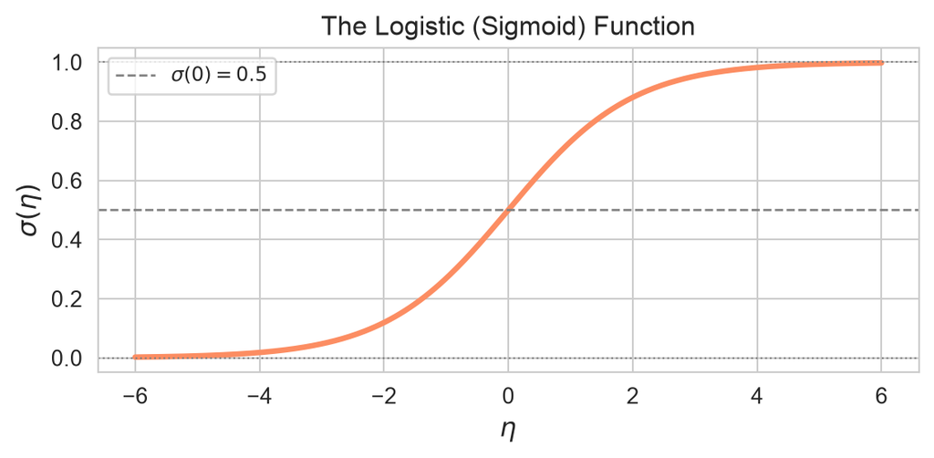

The logistic function maps any real number to the interval (0, 1).

```python
eta = np.linspace(-6, 6, 300)
fig, ax = plt.subplots(figsize=(6, 3))
ax.plot(eta, expit(eta), color='#fc8d62', lw=2.5)
ax.axhline(0.5, color='gray', lw=1, linestyle='--',
  label='$\\sigma(0)=0.5$')
ax.axhline(0,   color='gray', lw=0.8, linestyle=':')
ax.axhline(1,   color='gray', lw=0.8, linestyle=':')
ax.set_xlabel('$\\eta$', fontsize=12)
ax.set_ylabel('$\\sigma(\\eta)$', fontsize=12)
ax.set_title('The Logistic (Sigmoid) Function')
ax.legend(fontsize=9)
plt.tight_layout(); plt.show()
```

## Interpreting Logistic Regression Coefficients

### Three equivalent scales

| Scale | Formula | Interpretation |
| --- | --- | --- |
| **Log-odds** | $\log\frac{\pi}{1-\pi} = \boldsymbol{x}^\top\boldsymbol{\beta}$ | Linear, unbounded — the model lives here |
| **Odds** | $\frac{\pi}{1-\pi} = e^{\boldsymbol{x}^\top\boldsymbol{\beta}}$ | $e^{\beta_j}$ is the **odds ratio** per unit increase in $x_j$ |
| **Probability** | $\pi = \sigma(\boldsymbol{x}^\top\boldsymbol{\beta})$ | Non-linear; depends on the values of all predictors |

### Odds ratio interpretation

- If $\beta_j = 0.5$, then $e^{0.5} \approx 1.65$: a one-unit increase in $X_j$ **multiplies the odds** by $1.65$.
- If $\beta_j < 0$, the odds **decrease** with $X_j$ (odds ratio $< 1$).
- Odds ratios are **multiplicative**, not additive.

## The Log-Likelihood for Logistic Regression

Each observation contributes a Bernoulli log-likelihood:

$$\ell(\boldsymbol{\beta}) = \sum_{i=1}^n \left[y_i \log \pi_i + (1 - y_i)\log(1 - \pi_i)\right],$$

where $\pi_i = \sigma(\mathbf{x}_i^\top\boldsymbol{\beta})$.

- This is also called the **binary cross-entropy** (common in deep learning).
- The **score equations** (setting the gradient to zero) have no closed form.
- **IRLS** iterates weighted least squares regressions until convergence.

### Deviance in logistic regression

- The **null deviance** compares the intercept-only model to the saturated model.
- The **residual deviance** compares the fitted model to the saturated model.
- A **pseudo-$R^2$** is often computed as $1 - D/D_0$ (McFadden’s $R^2$).

# Logistic Regression in Python

## 🗂️ The Dataset: Titanic Survival

### Why Titanic?

- A classic binary classification problem: did a passenger survive ($Y = 1$) or not ($Y = 0$)?
- Predictors include passenger class, sex, age, and fare — a mix of numeric and categorical variables.
- Available directly via `seaborn`.

```python
titanic = (
    sns.load_dataset('titanic')
    [['survived', 'pclass', 'sex', 'age', 'fare', 'embark_town']]
    .dropna()
    .reset_index(drop=True)
)
titanic.head()
```

|  | survived | pclass | sex | age | fare | embark_town |
| --- | --- | --- | --- | --- | --- | --- |
| 0 | 0 | 3 | male | 22.0 | 7.2500 | Southampton |
| 1 | 1 | 1 | female | 38.0 | 71.2833 | Cherbourg |
| 2 | 1 | 3 | female | 26.0 | 7.9250 | Southampton |
| 3 | 1 | 1 | female | 35.0 | 53.1000 | Southampton |
| 4 | 0 | 3 | male | 35.0 | 8.0500 | Southampton |

## Exploratory Analysis

```python
fig, axes = plt.subplots(1, 2, figsize=(12, 4))

# By sex
sex_surv = titanic.groupby('sex')['survived'].mean().reset_index()
sns.barplot(data=sex_surv, x='sex', y='survived', ax=axes[0], palette='Set2')
axes[0].set_ylabel('Survival rate')
axes[0].set_title('Survival Rate by Sex')
axes[0].set_ylim(0, 1)

# By class
cls_surv = titanic.groupby('pclass', observed=True)['survived'].mean().reset_index()
sns.barplot(data=cls_surv, x='pclass', y='survived', ax=axes[1], palette='Set2')
axes[1].set_ylabel('Survival rate')
axes[1].set_xlabel('Passenger class')
axes[1].set_title('Survival Rate by Passenger Class')
axes[1].set_ylim(0, 1)

plt.suptitle('Titanic: Survival Rates by Demographic', fontsize=13, y=1.02)
plt.tight_layout(); plt.show()
```

## Exploratory Analysis

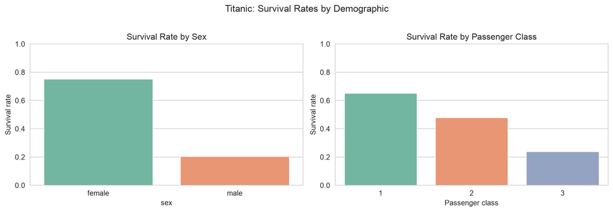

Survival rates by sex and passenger class. Women and first-class passengers had substantially higher survival rates.

## Age Distribution by Survival

```python
fig, ax = plt.subplots(figsize=(9, 4))
for label, grp in titanic.groupby('survived'):
    sns.kdeplot(grp['age'], ax=ax, fill=True, alpha=0.4,
                label='Survived' if label == 1 else 'Did not survive')
ax.set_xlabel('Age (years)')
ax.set_ylabel('Density')
ax.set_title('Age Distribution by Survival Outcome')
ax.legend()
plt.tight_layout(); plt.show()
```

## Age Distribution by Survival

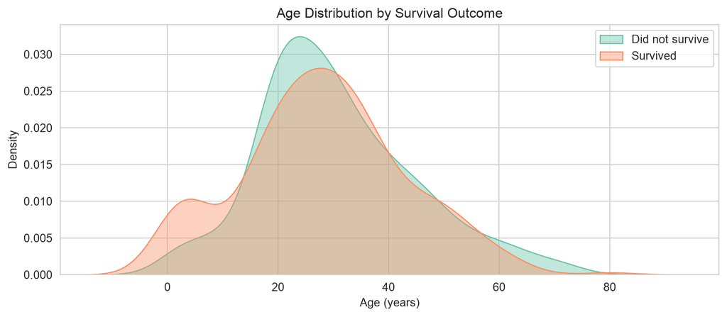

Age distributions for survivors and non-survivors. Children show a somewhat higher survival rate, consistent with the ‘women and children first’ policy.

## Fitting a Logistic Regression Model

### The formula interface

- `statsmodels` uses the same formula syntax as for OLS.
- We use `smf.logit(...)` instead of `smf.ols(...)`.
- Categorical variables are automatically dummy-coded with `C(...)`.

```python
logit1 = smf.logit(
    'survived ~ C(sex) + age + C(pclass) + fare',
    data=titanic
).fit()
print(logit1.summary())
```

```
Optimization terminated successfully.
         Current function value: 0.454099
         Iterations 6
                           Logit Regression Results
==============================================================================
Dep. Variable:               survived   No. Observations:                  712
Model:                          Logit   Df Residuals:                      706
Method:                           MLE   Df Model:                            5
Date:                Thu, 29 Oct 2026   Pseudo R-squ.:                  0.3271
Time:                        10:14:20   Log-Likelihood:                -323.32
converged:                       True   LL-Null:                       -480.45
Covariance Type:            nonrobust   LLR p-value:                 8.567e-66
==================================================================================
                     coef    std err          z      P>|z|      [0.025      0.975]
----------------------------------------------------------------------------------
Intercept          3.7150      0.464      7.998      0.000       2.805       4.625
C(sex)[T.male]    -2.5096      0.208    -12.041      0.000      -2.918      -2.101
C(pclass)[T.2]    -1.2682      0.313     -4.055      0.000      -1.881      -0.655
C(pclass)[T.3]    -2.5336      0.328     -7.728      0.000      -3.176      -1.891
age               -0.0369      0.008     -4.769      0.000      -0.052      -0.022
fare               0.0005      0.002      0.230      0.818      -0.004       0.005
==================================================================================
```

## Reading the Logistic Regression Summary

### Key output fields

| Output | Meaning |
| --- | --- |
| **Log-Likelihood** | Value of $\ell(\hat{\boldsymbol{\beta}})$ at convergence — higher is better |
| **LL-Null** | Log-likelihood of intercept-only model ($D_0 / {-2}$) |
| **Pseudo $R^2$** | McFadden’s: $1 - \ell(\hat{\boldsymbol{\beta}})/\ell_0$ |
| **Coef** | Log-odds coefficients $\hat{\beta}_j$ |
| **$P > \|z\|$** | Wald test $p$-value for $H_0: \beta_j = 0$ |
| **$[0.025,\, 0.975]$** | 95% confidence interval on the log-odds scale |

> Note: standard errors and tests are based on the **Wald statistic** $z = \hat{\beta}_j / \widehat{\text{SE}}(\hat{\beta}_j) \approx \mathcal{N}(0,1)$ — a large-sample result from maximum likelihood theory.

## Interpreting Coefficients as Odds Ratios

```python
coefs = logit1.params.drop('Intercept')
conf  = logit1.conf_int().drop('Intercept')
or_df = pd.DataFrame({
    'Predictor': coefs.index,
    'OR':     np.exp(coefs.values),
    'CI_low': np.exp(conf[0].values),
    'CI_high':np.exp(conf[1].values)
})

fig, ax = plt.subplots(figsize=(9, 4))
y_pos = np.arange(len(or_df))
ax.barh(y_pos, or_df['OR'], color='steelblue', alpha=0.75)
ax.errorbar(
    or_df['OR'], y_pos,
    xerr=[or_df['OR'] - or_df['CI_low'], or_df['CI_high'] - or_df['OR']],
    fmt='none', color='navy', capsize=4, lw=1.5
)
ax.axvline(1, color='crimson', lw=2, linestyle='--', label='OR = 1 (no effect)')
ax.set_yticks(y_pos)
ax.set_yticklabels(
    [s.replace('C(sex)[T.', '').replace('C(pclass)[T.', 'Class ').replace(']', '')
     for s in or_df['Predictor']],
    fontsize=10
)
ax.set_xlabel('Odds Ratio (95% CI)')
ax.set_title('Logistic Regression: Odds Ratios — Titanic Survival')
ax.legend(fontsize=9)
plt.tight_layout(); plt.show()
```

## Interpreting Coefficients as Odds Ratios

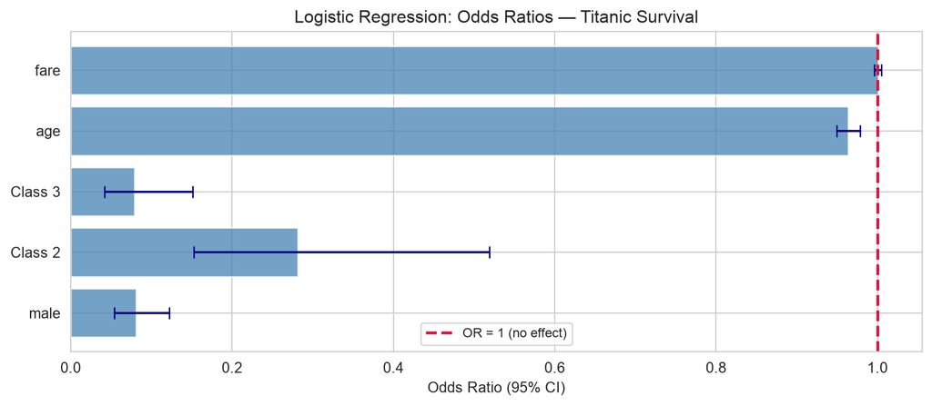

Odds ratios with 95% confidence intervals for the Titanic logistic regression. An odds ratio > 1 means increased odds of survival; < 1 means decreased odds.

## Predicted Probabilities

### The probability scale

- The coefficient table lives on the **log-odds** scale.
- For communication and decision-making we often want **predicted probabilities**.

```python
# Predicted probability for two hypothetical passengers
newdata = pd.DataFrame({
    'sex':    ['female', 'male'],
    'age':    [30, 30],
    'pclass': [1, 3],
    'fare':   [50, 10]
})
probs = logit1.predict(newdata)
for i, row in newdata.iterrows():
    print(f"  {row['sex']:6s}, age {row['age']}, class {row['pclass']}, "
          f"fare {row['fare']:.0f}: P(survive) = {probs[i]:.3f}")
```

```
  female, age 30, class 1, fare 50: P(survive) = 0.933
  male  , age 30, class 3, fare 10: P(survive) = 0.081
```

- A 30-year-old female in first class has a **high** predicted survival probability.
- A 30-year-old male in third class has a much **lower** probability.
- This matches the historical record.

## Visualising the Decision Boundary

```python
ages = np.linspace(1, 70, 200)
grid = pd.concat([
    pd.DataFrame({
        'age': ages, 'sex': 'female',
        'pclass': 3,
        'fare': titanic['fare'].median()
    }),
    pd.DataFrame({
        'age': ages, 'sex': 'male',
        'pclass': 3,
        'fare': titanic['fare'].median()
    })
], ignore_index=True)

grid['prob'] = logit1.predict(grid)

fig, ax = plt.subplots(figsize=(9, 4.5))
colors_sex = {'female': '#fc8d62', 'male': '#8da0cb'}
for sex, grp in grid.groupby('sex'):
    ax.plot(grp['age'], grp['prob'], lw=2.5,
            color=colors_sex[sex], label=sex.capitalize())

ax.axhline(0.5, color='gray', lw=1, linestyle='--', label='Threshold = 0.5')
ax.scatter(
    titanic.query("pclass == 3")['age'],
    titanic.query("pclass == 3")['survived'],
    c=titanic.query("pclass == 3")['sex'].map({'female': '#fc8d62', 'male': '#8da0cb'}),
    alpha=0.3, s=15, zorder=2
)
ax.set_xlabel('Age (years)')
ax.set_ylabel('$P(\\text{survived} = 1)$')
ax.set_title('Predicted Survival Probability — 3rd Class, Median Fare')
ax.legend(fontsize=9)
plt.tight_layout(); plt.show()
```

## Visualising the Decision Boundary

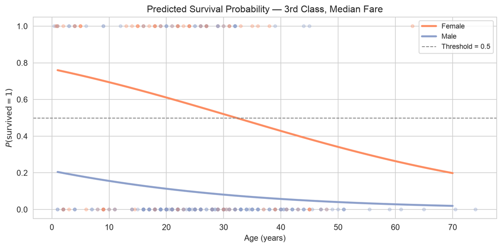

Predicted survival probability as a function of age, stratified by sex, for a third-class passenger with median fare. The logistic curve is clearly visible.

# Classification Performance

## ⚠️ A Note on Inference vs. Prediction

**In-sample evaluation**

- The classification metrics on the following slides — accuracy, confusion matrix, and ROC/AUC — are computed on the **same data used to fit the model**. This gives an **optimistic** picture of predictive performance: the model has already seen every observation it is being evaluated on.
- In a **prediction-focused** workflow you would split the data into a training set (for fitting) and a held-out test set (for evaluation) before reporting these metrics.
- Here, our primary goal is **inference** — understanding which predictors are associated with survival and by how much. For that purpose the full dataset is used, and the classification metrics are included only to illustrate how a fitted logistic regression translates into a classifier.

## 🎯 From Probabilities to Predictions

### Applying a threshold

- We classify $\hat{Y}_i = 1$ if $\hat{\pi}_i > \tau$, where $\tau$ is a **decision threshold** (default: $0.5$).

```python
pi_hat = logit1.predict()
y_pred = (pi_hat >= 0.5).astype(int)
y_true = titanic['survived'].values

# Accuracy
acc = (y_pred == y_true).mean()
print(f"Accuracy: {acc:.3f}")
```

```
Accuracy: 0.792
```

### The confusion matrix

- Accuracy alone can be misleading when classes are imbalanced.
- The **confusion matrix** breaks down predictions into four categories:

|  | Predicted 0 | Predicted 1 |
| --- | --- | --- |
| **True 0** | True negative (TN) | False positive (FP) |
| **True 1** | False negative (FN) | True positive (TP) |

## Confusion Matrix

```python
cm = confusion_matrix(y_true, y_pred)
fig, ax = plt.subplots(figsize=(6, 5))
ConfusionMatrixDisplay(cm, display_labels=['Did not survive', 'Survived']).plot(
    ax=ax, colorbar=False, cmap='Blues'
)
ax.set_title('Confusion Matrix — Logistic Regression (threshold = 0.5)', fontsize=11)
plt.tight_layout(); plt.show()
```

## Confusion Matrix

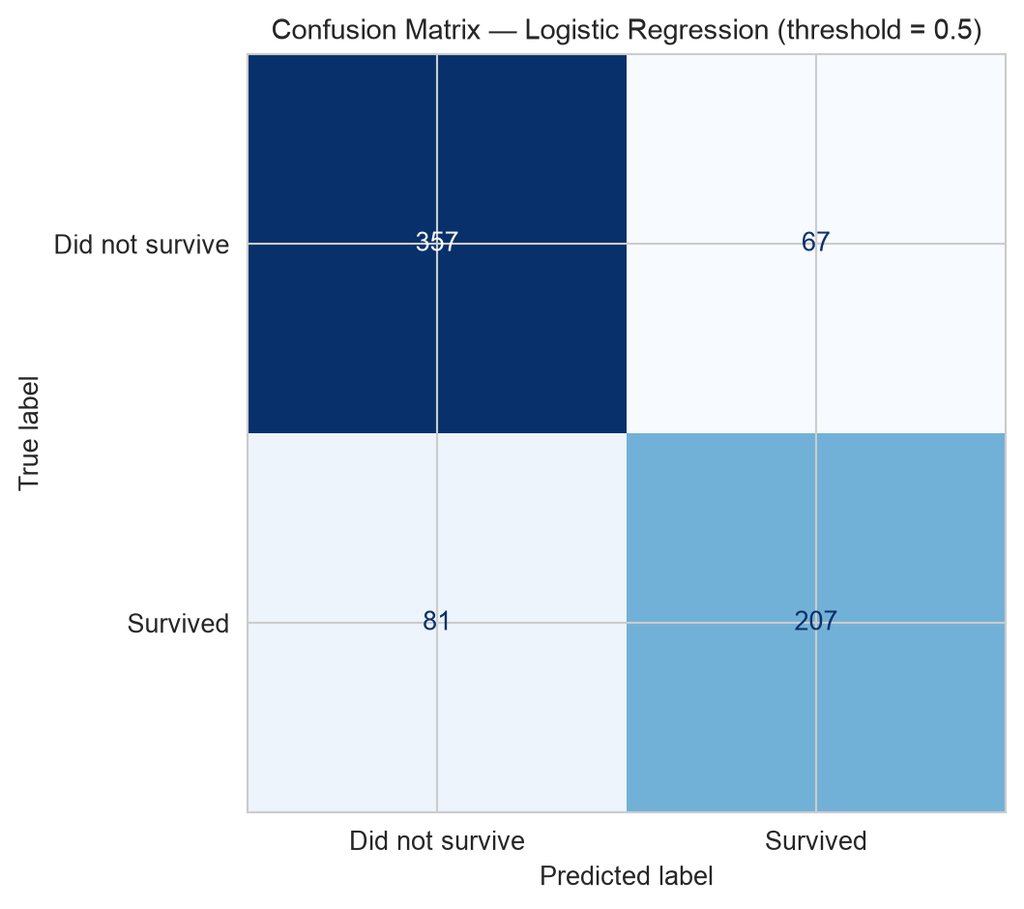

Confusion matrix for the logistic regression model at threshold 0.5 (in-sample). The model correctly classifies the majority of passengers, though these figures are optimistic without a held-out test set.

## The ROC Curve

The **Receiver Operating Characteristic (ROC) curve** plots the **true positive rate** (sensitivity) against the **false positive rate** (1 - specificity) as the threshold $\tau$ varies from 1 to 0.

- A **perfect classifier** has AUC (area under the ROC curve) $= 1$.
- A **random classifier** has AUC $= 0.5$ — the diagonal.
- AUC measures **overall discriminative ability**, independent of the chosen threshold.

```python
fpr, tpr, _ = roc_curve(y_true, pi_hat)
auc = roc_auc_score(y_true, pi_hat)

fig, ax = plt.subplots(figsize=(6, 5))
ax.plot(fpr, tpr, color='steelblue', lw=2.5,
        label=f'Logistic regression (AUC = {auc:.3f})')
ax.plot([0, 1], [0, 1], 'k--', lw=1.5, label='Random classifier (AUC = 0.5)')
ax.set_xlabel('False Positive Rate (1 - Specificity)')
ax.set_ylabel('True Positive Rate (Sensitivity)')
ax.set_title('ROC Curve — Titanic Logistic Regression')
ax.legend(fontsize=9)
plt.tight_layout(); plt.show()
```

## The ROC Curve

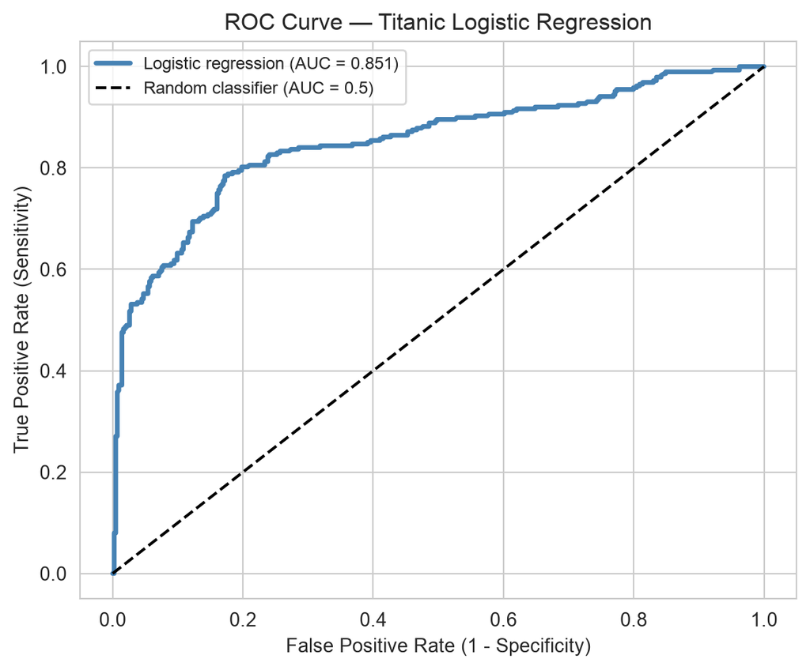

ROC curve for the logistic regression model (in-sample). AUC substantially above 0.5 indicates good discriminative power, though in a prediction workflow this would be evaluated on a held-out test set.

## Model Comparison with the LRT

### Does adding `embark_town` improve the model?

```python
logit2 = smf.logit(
    'survived ~ C(sex) + age + C(pclass) + fare + C(embark_town)',
    data=titanic
).fit(disp=False)

# Likelihood ratio test statistic
G2 = 2 * (logit2.llf - logit1.llf)
dof = logit2.df_model - logit1.df_model
from scipy.stats import chi2
p_lrt = chi2.sf(G2, df=dof)
print(f"LRT G² = {G2:.3f},  df = {int(dof)},  p-value = {p_lrt:.4f}")
```

```
LRT G² = 3.964,  df = 2,  p-value = 0.1378
```

```python
# AIC / BIC comparison
print(f"{'Model':<30} {'AIC':>8} {'BIC':>8} {'Pseudo R²':>10}")
print("-" * 58)
for name, m in [('Without embark_town', logit1), ('With embark_town', logit2)]:
    pr2 = 1 - m.llf / m.llnull
    print(f"{name:<30} {m.aic:>8.2f} {m.bic:>8.2f} {pr2:>10.4f}")
```

```
Model                               AIC      BIC  Pseudo R²
----------------------------------------------------------
Without embark_town              658.64   686.05     0.3271
With embark_town                 658.67   695.22     0.3312
```

# Poisson Regression

## 🔢 Modelling Count Data

### When the response is a count

- Counts are **non-negative integers**: $Y_i \in \{0, 1, 2, \ldots\}$.
- A natural model is $Y_i \sim \text{Poisson}(\lambda_i)$, with $\mathbb{E}[Y_i] = \lambda_i > 0$.
- Recall that for the Poisson distribution, $\text{Var}(Y_i) = \lambda_i = \mathbb{E}[Y_i]$ — **variance equals the mean**.

### The Poisson regression model

We use the **log link** to ensure $\lambda_i > 0$:

$$\log \lambda_i = \mathbf{x}_i^\top\boldsymbol{\beta} = \beta_0 + \beta_1 x_{i1} + \cdots + \beta_p x_{ip}.$$

Taking the exponential: $\lambda_i = e^{\mathbf{x}_i^\top\boldsymbol{\beta}}$.

## Interpreting Poisson Regression Coefficients

| Coefficient | Interpretation |
| --- | --- |
| $\beta_j$ | A one-unit increase in $X_j$ **adds** $\beta_j$ to $\log\lambda$ |
| $e^{\beta_j}$ | A one-unit increase in $X_j$ **multiplies** $\lambda$ by $e^{\beta_j}$ |
| $e^{\beta_j} > 1$ | The expected count **increases** |
| $e^{\beta_j} < 1$ | The expected count **decreases** |

- Coefficients are on the **log scale** — like logistic regression, back-transform with $e^{\hat{\beta}_j}$ for multiplicative interpretation.
- The **incidence rate ratio** $e^{\hat{\beta}_j}$ is the Poisson analogue of the odds ratio.

## Poisson Regression in Python

### Dataset: simulated daily bike rentals

We simulate a dataset of daily bicycle rental counts with weather and calendar predictors — the structure mirrors real bike-sharing data and lets us verify that the model recovers known coefficients.

```python
rng_b = np.random.default_rng(2024)
n_b = 500
temp_b = rng_b.uniform(0.05, 0.95, n_b)   # normalised temperature
hum_b = rng_b.uniform(0.30, 0.95, n_b)   # normalised humidity
wind_b = rng_b.uniform(0.00, 0.50, n_b)   # normalised windspeed
season_b = rng_b.choice([1, 2, 3, 4], n_b)  # 1=Spring … 4=Winter
working_b = rng_b.choice([0, 1], n_b)        # 1=working day

# True log-linear mean: known parameters
log_lam = (
    5.5
    + 1.8 * temp_b
    - 1.2 * hum_b
    - 0.6 * wind_b
    + 0.3 * (season_b == 2).astype(float)   # Summer boost
    + 0.1 * (season_b == 3).astype(float)   # Autumn boost
    - 0.1 * (season_b == 4).astype(float)   # Winter dip
    + 0.15 * working_b
)
cnt_b = rng_b.poisson(np.exp(log_lam))

bikes = pd.DataFrame({
    'cnt': cnt_b, 'temp': temp_b, 'hum': hum_b,
    'windspeed': wind_b, 'season': season_b, 'workingday': working_b
})
print(bikes.describe().round(2))
```

```
           cnt    temp     hum  windspeed  season  workingday
count   500.00  500.00  500.00     500.00  500.00       500.0
mean    316.72    0.48    0.64       0.27    2.49         0.5
std     187.51    0.26    0.19       0.14    1.10         0.5
min      70.00    0.05    0.30       0.00    1.00         0.0
25%     177.75    0.25    0.47       0.15    2.00         0.0
50%     269.00    0.49    0.65       0.27    2.00         0.0
75%     404.25    0.71    0.82       0.39    3.00         1.0
max    1344.00    0.95    0.95       0.50    4.00         1.0
```

## Counts and Predictors

```python
fig, axes = plt.subplots(2, 2, figsize=(13, 6))

sns.histplot(bikes['cnt'], bins=40, ax=axes[0,0], color='steelblue')
axes[0,0].set_xlabel('Daily rentals'); axes[0,0].set_title('Distribution of Rental Counts')

axes[0,1].scatter(bikes['temp'], bikes['cnt'], alpha=0.25, s=10, color='steelblue')
axes[0,1].set_xlabel('Normalised temperature'); axes[0,1].set_ylabel('Rentals')
axes[0,1].set_title('Rentals vs. Temperature')

axes[1,0].scatter(bikes['hum'], bikes['cnt'], alpha=0.25, s=10, color='#fc8d62')
axes[1,0].set_xlabel('Normalised humidity'); axes[1,0].set_ylabel('Rentals')
axes[1,0].set_title('Rentals vs. Humidity')

sns.boxplot(data=bikes, x='season', y='cnt', ax=axes[1,1], palette='Set2')
axes[1,1].set_xlabel('Season (1=Spring … 4=Winter)'); axes[1,1].set_ylabel('Rentals')
axes[1,1].set_title('Rentals by Season')

plt.suptitle('Daily Bike Rentals — Exploratory Analysis', fontsize=13, y=1.01)
plt.tight_layout(); plt.show()
```

## Counts and Predictors

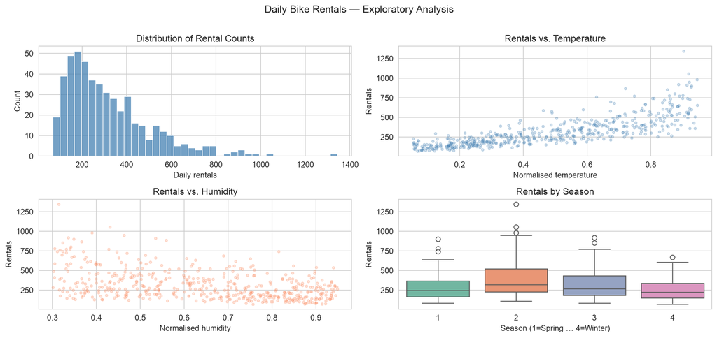

Daily bike rental counts: right-skewed distribution (top left) and relationship with temperature (top right) and humidity (bottom left). Season effects are visible in the box plots (bottom right).

## Fitting the Poisson Model

```python
poisson1 = smf.poisson(
    'cnt ~ temp + hum + windspeed + C(season) + workingday',
    data=bikes
).fit()
print(poisson1.summary())
```

```
Optimization terminated successfully.
         Current function value: 4.250748
         Iterations 5
                          Poisson Regression Results
==============================================================================
Dep. Variable:                    cnt   No. Observations:                  500
Model:                        Poisson   Df Residuals:                      492
Method:                           MLE   Df Model:                            7
Date:                Thu, 29 Oct 2026   Pseudo R-squ.:                  0.9204
Time:                        10:14:20   Log-Likelihood:                -2125.4
converged:                       True   LL-Null:                       -26687.
Covariance Type:            nonrobust   LLR p-value:                     0.000
==================================================================================
                     coef    std err          z      P>|z|      [0.025      0.975]
----------------------------------------------------------------------------------
Intercept          5.5235      0.013    428.101      0.000       5.498       5.549
C(season)[T.2]     0.2826      0.007     40.687      0.000       0.269       0.296
C(season)[T.3]     0.0801      0.008     10.667      0.000       0.065       0.095
C(season)[T.4]    -0.1084      0.008    -13.792      0.000      -0.124      -0.093
temp               1.7894      0.010    175.609      0.000       1.769       1.809
hum               -1.2198      0.013    -93.153      0.000      -1.245      -1.194
windspeed         -0.5851      0.018    -32.299      0.000      -0.621      -0.550
workingday         0.1571      0.005     30.955      0.000       0.147       0.167
==================================================================================
```

## Interpreting the Poisson Coefficients

```python
coefs_p = poisson1.params.drop('Intercept')
conf_p  = poisson1.conf_int().drop('Intercept')
irr_df = pd.DataFrame({
    'Predictor': coefs_p.index,
    'IRR':     np.exp(coefs_p.values),
    'CI_low':  np.exp(conf_p[0].values),
    'CI_high': np.exp(conf_p[1].values)
})

fig, ax = plt.subplots(figsize=(9, 4.5))
y_pos = np.arange(len(irr_df))
ax.barh(y_pos, irr_df['IRR'], color='#8da0cb', alpha=0.8)
ax.errorbar(
    irr_df['IRR'], y_pos,
    xerr=[irr_df['IRR'] - irr_df['CI_low'], irr_df['CI_high'] - irr_df['IRR']],
    fmt='none', color='navy', capsize=4, lw=1.5
)
ax.axvline(1, color='crimson', lw=2, linestyle='--', label='IRR = 1 (no effect)')
labels_p = [s.replace('C(season)[T.', 'Season ').replace(']', '') for s in irr_df['Predictor']]
ax.set_yticks(y_pos); ax.set_yticklabels(labels_p, fontsize=10)
ax.set_xlabel('Incidence Rate Ratio (95% CI)')
ax.set_title('Poisson Regression: Incidence Rate Ratios — Daily Bike Rentals')
ax.legend(fontsize=9)
plt.tight_layout(); plt.show()
```

## Interpreting the Poisson Coefficients

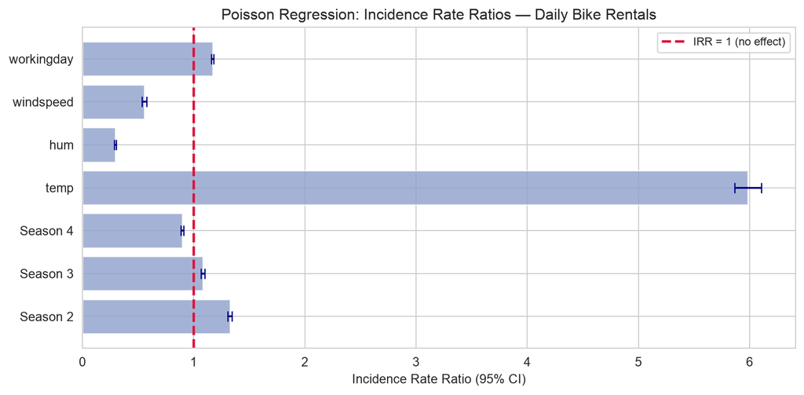

Incidence rate ratios (IRR = exp(β̂)) with 95% CIs. An IRR > 1 means more rentals; < 1 means fewer rentals per unit increase in the predictor.

## Poisson Fit: Observed vs. Fitted

```python
fitted_p = np.exp(poisson1.fittedvalues)

fig, axes = plt.subplots(1, 2, figsize=(13, 5))

axes[0].scatter(fitted_p, bikes['cnt'], alpha=0.3, s=12, color='steelblue')
lims = [0, max(bikes['cnt'].max(), fitted_p.max()) + 100]
axes[0].plot(lims, lims, 'k--', lw=1.5, label='Perfect fit')
axes[0].set_xlim(lims)
axes[0].set_ylim(lims)
axes[0].set_xlabel('Fitted $\\hat{\\lambda}$'); axes[0].set_ylabel('Observed count')
axes[0].set_title('Observed vs. Fitted — Poisson Model')
axes[0].legend()

pearson_resid = (bikes['cnt'] - fitted_p) / np.sqrt(fitted_p)
axes[1].scatter(fitted_p, pearson_resid, alpha=0.3, s=12, color='steelblue')
axes[1].axhline(0, color='crimson', lw=1.5, linestyle='--')
axes[1].set_xlabel('Fitted $\\hat{\\lambda}$')
axes[1].set_ylabel('Pearson residual')
axes[1].set_title('Pearson Residuals vs. Fitted — Poisson Model')

plt.suptitle('Poisson Regression Diagnostics — Bike Rentals', fontsize=13, y=1.01)
plt.tight_layout(); plt.show()
```

## Poisson Fit: Observed vs. Fitted

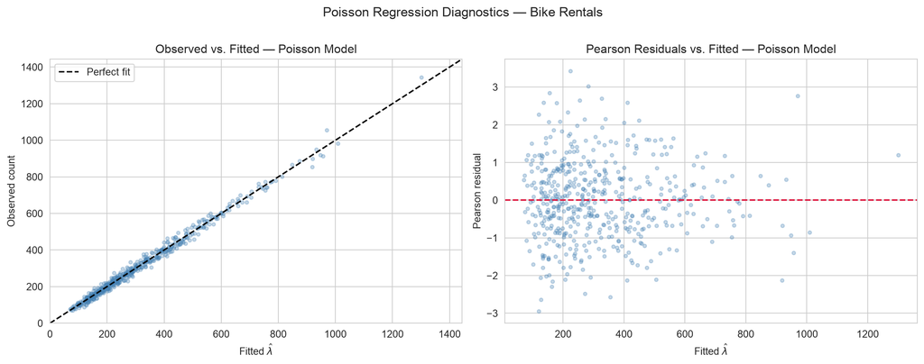

Observed vs. fitted rental counts for the Poisson model. Points near the diagonal indicate good fit; the spread increases at larger counts, consistent with the Poisson mean–variance relationship.

# GLM Diagnostics and Assumptions

## 🔬 Residuals for GLMs

### What changes from OLS?

- In OLS, residuals $e_i = y_i - \hat{y}_i$ have constant variance under the model.
- In GLMs, the **variance of $Y_i$ depends on the mean** — so raw residuals are not comparable across observations.

### Two useful residual types

| Residual | Formula | Use |
| --- | --- | --- |
| **Pearson** | $r_i = (y_i - \hat{\mu}_i)/\sqrt{\hat{V}(\hat{\mu}_i)}$ | Variance-standardised; detect outliers |
| **Deviance** | $d_i = \text{sign}(y_i - \hat{\mu}_i)\sqrt{2[y_i\log(y_i/\hat{\mu}_i) - (y_i - \hat{\mu}_i)]}$ | Contribution to total deviance |

- Under a well-fitting GLM, both should look **approximately $\mathcal{N}(0,1)$** with no pattern against fitted values.

## Residual Distributions: Bike-Rental Example

```python
from scipy.stats import norm

fig, axes = plt.subplots(1, 2, figsize=(12, 5))

z = np.linspace(-4, 4, 300)

# Pearson residuals
axes[0].hist(poisson1.resid_pearson, bins=35, density=True,
             color='steelblue', alpha=0.75, edgecolor='white')
axes[0].plot(z, norm.pdf(z), 'k-', lw=2, label='$\\mathcal{N}(0,1)$')
axes[0].axvline(0, color='crimson', lw=1.5, linestyle='--')
axes[0].set_xlabel('Pearson residual $r_i$')
axes[0].set_ylabel('Density')
axes[0].set_title('Pearson Residuals')
axes[0].legend()

# Deviance residuals — computed manually (PoissonResults lacks resid_deviance)
# Use predict() for count-scale mu (fittedvalues returns the linear predictor)
mu_hat = poisson1.predict()
y_b = bikes['cnt'].values.astype(float)
log_term = np.where(y_b > 0, y_b * np.log(y_b / mu_hat), 0.0)
dev_resid = np.sign(y_b - mu_hat) * np.sqrt(2 * (log_term - (y_b - mu_hat)))

axes[1].hist(dev_resid, bins=35, density=True,
             color='#8da0cb', alpha=0.75, edgecolor='white')
axes[1].plot(z, norm.pdf(z), 'k-', lw=2, label='$\\mathcal{N}(0,1)$')
axes[1].axvline(0, color='crimson', lw=1.5, linestyle='--')
axes[1].set_xlabel('Deviance residual $d_i$')
axes[1].set_ylabel('Density')
axes[1].set_title('Deviance Residuals')
axes[1].legend()

plt.suptitle('GLM Residual Distributions — Poisson Bike-Rental Model', fontsize=13, y=1.01)
plt.tight_layout(); plt.show()
```

## Residual Distributions: Bike-Rental Example

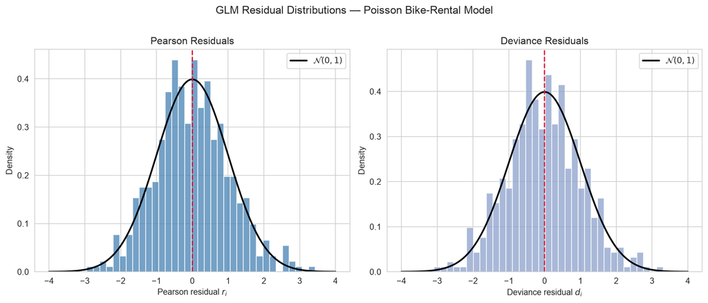

Histograms of Pearson and deviance residuals from the Poisson bike-rental model, with a standard normal density overlaid. Both distributions are centred near zero and approximately bell-shaped, consistent with a well-fitting model.

## GLM Assumptions: What Must Hold?

### Core assumptions

| Assumption | How to check |
| --- | --- |
| **Correct distribution family** | Residual plots; compare AIC across families |
| **Correct link function** | Component-plus-residual plots; try alternative links |
| **Correct linear predictor** | Residuals vs. each predictor; added-variable plots |
| **Independence of observations** | Study design; check for clusters or time structure |
| **No influential observations** | Cook’s distance; leverage |

### What we *don’t* need for GLMs

- **Constant error variance** — variance is explicitly modelled as a function of $\mu$.
- **Normally distributed errors** — the exponential family replaces Gaussianity.

## Overdispersion in Poisson Regression

**Overdispersion**

**Overdispersion** occurs when the observed variance **exceeds** the variance assumed by the model. For Poisson regression, the model assumes $\text{Var}(Y_i) = \lambda_i$. If the true variance is $\phi \lambda_i$ with $\phi > 1$, the data are overdispersed.

- **Consequence**: standard errors are underestimated, $p$-values are too small.
- **Diagnose**: compute the **dispersion statistic** $\hat{\phi} = \chi^2_P / (n - p - 1)$, where $\chi^2_P = \sum r_i^2$ is the Pearson chi-squared.
- **Remedies**: use a **quasi-Poisson** model (estimate $\phi$ from the data) or the **negative binomial** distribution.

```python
pearson_chi2 = np.sum(
    (bikes['cnt'] - poisson1.predict())**2
    / poisson1.predict()
)
phi_hat = pearson_chi2 / poisson1.df_resid
print(f"Pearson χ² / df = {phi_hat:.2f}")
print("Overdispersed" if phi_hat > 1.5 else "Dispersion OK")
```

```
Pearson χ² / df = 1.08
Dispersion OK
```

# Comparing Linear and Generalized Linear Models

## 🗺️ The Big Picture

| Feature | Linear Regression | GLM |
| --- | --- | --- |
| **Response type** | Continuous, unbounded | Exponential family (binary, count, …) |
| **Error distribution** | Normal | Flexible |
| **Mean function** | $\mu = \mathbf{x}^\top\boldsymbol{\beta}$ (identity link) | $g(\mu) = \mathbf{x}^\top\boldsymbol{\beta}$ |
| **Estimation** | OLS (closed-form) | MLE via IRLS (iterative) |
| **Residual measure** | RSS | Deviance |
| **Model comparison** | $F$-test, AIC, BIC | LRT ($G^2$, $\chi^2$), AIC, BIC |
| **Coefficient interpretation** | Additive effect on $\mu$ | Additive effect on $g(\mu)$; back-transform for multiplicative interpretation |

> Linear regression is itself a GLM — Normal family, identity link. The framework unifies what might otherwise appear to be separate methods.

## Conclusion

### ✅ What we covered

- **Limits of OLS**: why linear regression is unsuitable for binary, count, and other non-Gaussian responses.
- **GLM framework**: the three components (random, systematic, link); the exponential family; maximum likelihood estimation via IRLS.
- **Deviance and LRT**: GLM analogues of RSS, $R^2$, and the $F$-test.
- **Logistic regression**: logit link; log-odds and odds ratio interpretation; Wald tests; predicted probabilities; confusion matrix; ROC curve and AUC.
- **Poisson regression**: log link; incidence rate ratio interpretation; overdispersion and the dispersion statistic.
- **GLM diagnostics**: Pearson and deviance residuals; assumptions; overdispersion.
- **Unified view**: linear regression as a special case of the GLM framework.

### 📅 What’s next?

- **Model Selection and Regularization**: variable selection strategies (stepwise, best subsets), ridge regression, LASSO, and cross-validation — applicable to both linear models and GLMs.